# Deaging and Harmonization procedures

Fernanda Hansen P. de Moraes

# Setup

```r
# set working directory
setwd("~/GitHub/CorticalFoldingHumans_deaging_harmonization")
```

```r
# load packages ----
library(tidyverse)
library(readxl)
library(stringr)
library(lubridate)
library(kableExtra)
library(ggpubr)
library(broom)
library(MASS)
library(irr)
library(effects)
library(lme4)
library(lsmeans)
```

```r
# load datasets ----
# removing OASIS as it does not have lobes information

data <- read_csv("data.csv") %>%
  filter(Sample != "OASIS")
```

```r
# estimate localGI, k, K, S and I
# correct for gaussian curvature for lobes estimates
# estimate localGI, k, K, S and I for lobes

data <- data %>%
  mutate(
    logAvgThickness = log10(AvgThickness),
    logTotalArea = log10(TotalArea),
    logExposedArea = log10(ExposedArea),
    localGI = TotalArea / ExposedArea,
    k = sqrt(AvgThickness) * TotalArea / (ExposedArea ^ 1.25),
    K = 1 / 4 * log10(AvgThickness^ 2)  + log10(TotalArea) - 5 / 4 * log10(ExposedArea),
    S = 3 / 2 * log10(TotalArea) + 3 / 4 * log10(ExposedArea) - 9 /  4 * log10(AvgThickness^ 2)  ,
    I = log10(TotalArea) + log10(ExposedArea) + log10(AvgThickness^ 2)  ,
    Knorm = K / sqrt(1 + (1 / 4) ^ 2 + (5 / 4) ^ 2),
    Snorm = S / sqrt((3 / 2) ^ 2 + (3 / 4) ^ 2 + (9 / 4) ^ 2),
    Inorm = I / sqrt(1 ^ 2 + 1 ^ 2 + 1 ^ 2),
    c = as.double(ifelse(ROI == "hemisphere", NA, 4 * pi / GaussianCurvature)),
    TotalArea_corrected = ifelse(ROI == "hemisphere", TotalArea, TotalArea * c),
    ExposedArea_corrected = ifelse(ROI == "hemisphere", ExposedArea, ExposedArea * c),
    logTotalArea_corrected = log10(TotalArea_corrected),
    logExposedArea_corrected = log10(ExposedArea_corrected),
    localGI_corrected = TotalArea_corrected / ExposedArea_corrected,
    k_corrected = sqrt(AvgThickness) * TotalArea_corrected / (ExposedArea_corrected ^ 1.25),
    K_corrected = log10(TotalArea_corrected) - 5 / 4 * log10(ExposedArea_corrected) + 1 / 4 * log10(AvgThickness^ 2) ,
    I_corrected = log10(TotalArea_corrected) + log10(ExposedArea_corrected) + log10(AvgThickness^ 2) ,
    S_corrected = 3 / 2 * log10(TotalArea_corrected) + 3 / 4 * log10(ExposedArea_corrected) - 9 /  4 * log10(AvgThickness^ 2)
  )
```

```r
# Define variables as factor ----
data$ROI <- as.factor(data$ROI)
data$Diagnostic <- as.factor(data$Diagnostic)
data$Sample <- as.factor(data$Sample)
data$Gender <- as.factor(data$Gender)
```

```r
# select CTL subjects ----

data <- data %>% filter(Diagnostic == "CTL")
```

```r
# target age for deaging ----
Age.cor = 0
```

# Dataset description

| Sample | N | age | age_range | AvgT | AT | AE |
| --- | --- | --- | --- | --- | --- | --- |
| ADNI | 868 | 75 ± 6.5 | 56 ; 96 | 2.4 ± 0.11 | 97000 ± 8400 | 39000 ± 2700 |
| AHEAD | 100 | 42 ± 19 | 24 ; 76 | 2.6 ± 0.15 | 110000 ± 10000 | 39000 ± 2700 |
| AOMICPIOP1 | 208 | 22 ± 1.8 | 18 ; 26 | 2.6 ± 0.084 | 110000 ± 10000 | 40000 ± 2700 |
| AOMICPIOP2 | 224 | 22 ± 1.8 | 18 ; 26 | 2.6 ± 0.089 | 110000 ± 9100 | 39000 ± 2700 |
| HCPr900 | 881 | 29 ± 3.6 | 24 ; 37 | 2.7 ± 0.09 | 110000 ± 11000 | 40000 ± 3000 |
| IXI | 563 | 49 ± 16 | 20 ; 86 | 2.5 ± 0.14 | 97000 ± 10000 | 39000 ± 3100 |
| NKI | 168 | 34 ± 19 | 4 ; 85 | 2.5 ± 0.14 | 110000 ± 11000 | 40000 ± 2800 |

| Sample | N | age | age_range | K | S | I |
| --- | --- | --- | --- | --- | --- | --- |
| ADNI | 868 | 75 ± 6.5 | 56 ; 96 | -0.56 ± 0.017 | 9.2 ± 0.13 | 10 ± 0.074 |
| AHEAD | 100 | 42 ± 19 | 24 ; 76 | -0.5 ± 0.023 | 9.2 ± 0.13 | 10 ± 0.094 |
| AOMICPIOP1 | 208 | 22 ± 1.8 | 18 ; 26 | -0.49 ± 0.014 | 9.1 ± 0.094 | 10 ± 0.078 |
| AOMICPIOP2 | 224 | 22 ± 1.8 | 18 ; 26 | -0.51 ± 0.013 | 9.1 ± 0.093 | 10 ± 0.078 |
| HCPr900 | 881 | 29 ± 3.6 | 24 ; 37 | -0.5 ± 0.013 | 9.1 ± 0.11 | 10 ± 0.082 |
| IXI | 563 | 49 ± 16 | 20 ; 86 | -0.56 ± 0.022 | 9.2 ± 0.14 | 10 ± 0.1 |
| NKI | 168 | 34 ± 19 | 4 ; 85 | -0.52 ± 0.027 | 9.2 ± 0.12 | 10 ± 0.094 |

# Deaging

## Is it a linear function?

Visual verification of morphological variables behaviour with aging. Considering not all brain regions ages in the same rate, we split it in the desired ROI.

### For the hemisphere

#### Base measurements

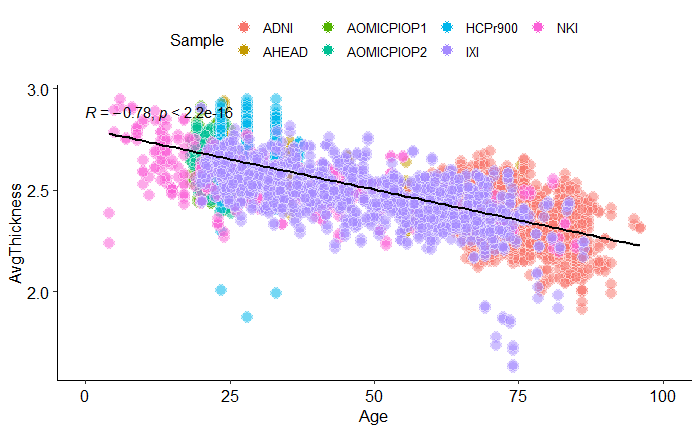

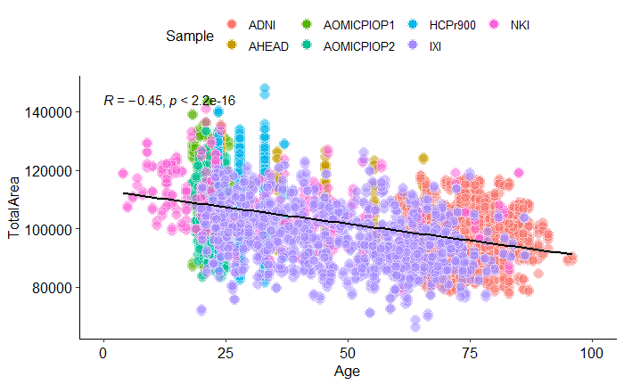

```r
ap1_b <- ggplot(filter(data, ROI == "hemisphere"), aes(x = Age, y = TotalArea)) +
  geom_point(aes(alpha =0.4, color = Sample, fill = Sample ),
             size = 4,
             pch = 21,
             colour = 'white') +
  geom_smooth(method = "lm", color = "black") +
  stat_cor() +
    guides(alpha= "none") +
  theme_pubr()+
    scale_x_continuous(name ="Age",
                    limits=c(0,100),
                breaks=c(seq(0,100,25)))

ap1_b
```

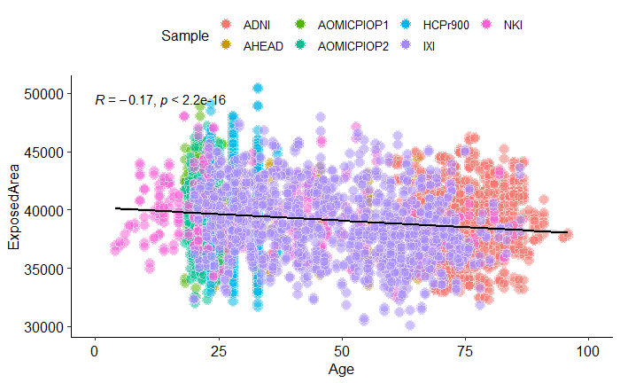

```r
ap1_c <- ggplot(filter(data, ROI == "hemisphere"), aes(x = Age, y = ExposedArea)) +
  geom_point(aes(alpha =0.4, color = Sample, fill = Sample ),
             size = 4,
             pch = 21,
             colour = 'white') +
  geom_smooth(method = "lm", color = "black") +
  stat_cor() +
    guides(alpha= "none") +
  theme_pubr()+
    scale_x_continuous(name ="Age",
                    limits=c(0,100),
                breaks=c(seq(0,100,25)))

ap1_c
```

#### Novel measurements

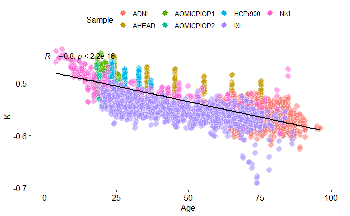

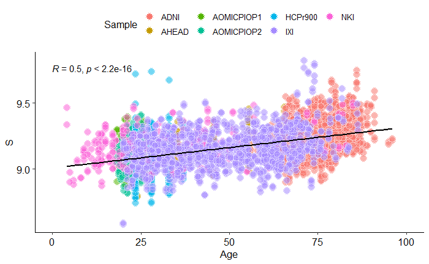

```r
ap1_e <- ggplot(filter(data, ROI == "hemisphere"), aes(x = Age, y = S)) +
  geom_point(aes(alpha =0.4, color = Sample, fill = Sample ),
             size = 4,
             pch = 21,
             colour = 'white') +
  geom_smooth(method = "lm", color = "black") +
  stat_cor() +
    guides(alpha= "none") +
  theme_pubr()+
    scale_x_continuous(name ="Age",
                    limits=c(0,100),
                breaks=c(seq(0,100,25)))

ap1_e
```

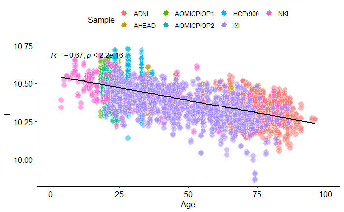

```r
ap1_f <- ggplot(filter(data, ROI == "hemisphere"), aes(x = Age, y = I)) +
  geom_point(aes(alpha =0.4, color = Sample, fill = Sample),
             size = 4,
             pch = 21,
             colour = 'white') +
  geom_smooth(method = "lm", color = "black") +
  stat_cor() +
  guides(alpha= "none") +
  theme_pubr()+
    scale_x_continuous(name ="Age",
                    limits=c(0,100),
                breaks=c(seq(0,100,25)))

ap1_f
```

```r
# Generate and save figures
ap1 <-
  ggarrange(ap1_a, ap1_b, ap1_c, ap1_d, ap1_e, ap1_f, labels = c("A","B", "C", "D", "E", "F"), nrow = 3, ncol = 2, font.label = list(size = 11), common.legend = TRUE, legend = "top")

ggsave("ap1.pdf", ap1, dpi=1200, width = 17.8, height = 17.8, units = "cm", device = "pdf")
```

### For the lobes

#### Base measurements

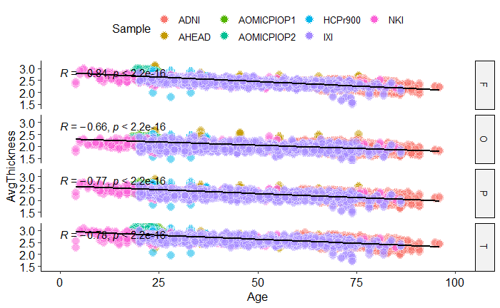

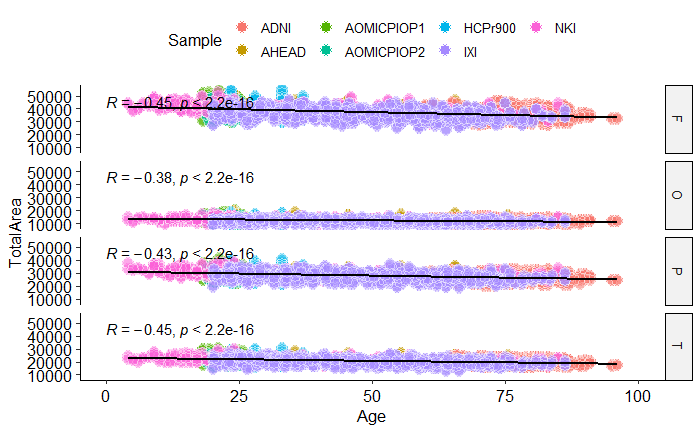

```r
ggplot(filter(data, ROI != "hemisphere"), aes(x = Age, y = TotalArea)) +
  geom_point(aes(alpha =0.4, color = Sample, fill = Sample),
             size = 4,
             pch = 21,
             colour = 'white') +
  geom_smooth(method = "lm", color = "black") +
  stat_cor() +
  facet_grid(ROI ~ .) +
      guides(alpha= "none") +
  theme_pubr()+
    scale_x_continuous(name ="Age",
                    limits=c(0,100),
                breaks=c(seq(0,100,25)))
```

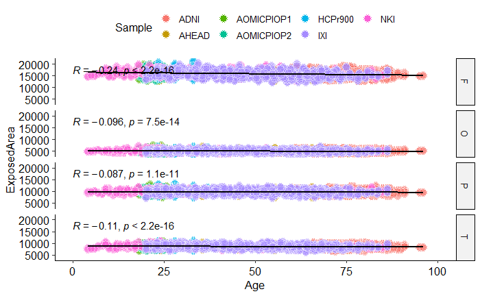

```r
ggplot(filter(data, ROI != "hemisphere"), aes(x = Age, y = ExposedArea)) +
  geom_point(aes(alpha =0.4, color = Sample, fill = Sample),
             size = 4,
             pch = 21,
             colour = 'white') +
  geom_smooth(method = "lm", color = "black") +
  stat_cor() +
  facet_grid(ROI ~ .) +
      guides(alpha= "none") +
  theme_pubr()+
    scale_x_continuous(name ="Age",
                    limits=c(0,100),
                breaks=c(seq(0,100,25)))
```

#### Novel measurements

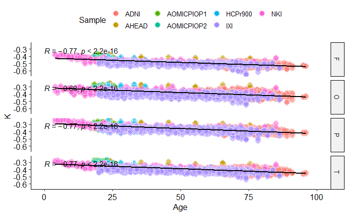

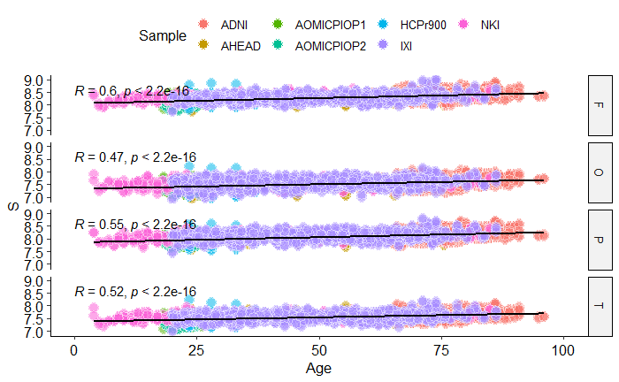

```r
ggplot(filter(data, ROI != "hemisphere"), aes(x = Age, y = S)) +
  geom_point(aes(alpha =0.4, color = Sample, fill = Sample),
             size = 4,
             pch = 21,
             colour = 'white') +
  geom_smooth(method = "lm", color = "black") +
  stat_cor() +
  facet_grid(ROI ~ .) +
      guides(alpha= "none") +
  theme_pubr() +
    scale_x_continuous(name ="Age",
                    limits=c(0,100),
                breaks=c(seq(0,100,25)))
```

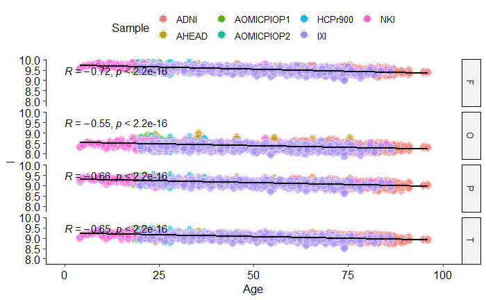

```r
ggplot(filter(data, ROI != "hemisphere"), aes(x = Age, y = I)) +
  geom_point(aes(alpha =0.4, color = Sample, fill = Sample),
             size = 4,
             pch = 21,
             colour = 'white') +
  geom_smooth(method = "lm", color = "black") +
  stat_cor() +
  facet_grid(ROI ~ .) +
      guides(alpha= "none") +
  theme_pubr() +
    scale_x_continuous(name ="Age",
                    limits=c(0,100),
                breaks=c(seq(0,100,25)))
```

## Removing age effect - substracting the slope

We remove the age effect at the *base* measurements, Total Area, Exposed Area and Cortical Thickness.

For the deaging process, we use Robust Linear Regressions, as it give weights to each data point and reduce the effects of outliers.

The deaging process **NEED** to be based on **CONTROL** values. Age also affects brain structure, as seens in the figures above. If the deaging process was based on all subjects, we could remove the disease effect across aging. Also, the deaging process is unique for each ROI. Therefore, we regress the variable for each ROI in an independent process here.

Further, we also need to separate for each Sample. All humans tends to have the same behaviour, but heterogeneous acquisition and processing could imply in a Type II Error addition in the results. This will be handle by the harmonization process.

```r
## AvgThickness ---
# select only CTL subjects with logAvgThickness values.
# divide by each ROI and sample
# perform the robust linear regression and visualize all results as a data frame

decay_AvgThickness <-
  filter(data, Diagnostic == "CTL", !is.na(AvgThickness), !is.nan(AvgThickness), !is.infinite(AvgThickness)) %>%
  droplevels() %>%
  group_by(ROI, Sample) %>%
  do(fit_decay_AvgThickness = tidy(rlm(AvgThickness ~ Age, data = .), conf.int=TRUE)) %>% unnest(cols = c(fit_decay_AvgThickness))

# display the results for example
decay_AvgThickness %>%
  filter(ROI == "hemisphere") %>%
  kable() %>%
  kable_styling()
```

| ROI | Sample | term | estimate | std.error | statistic | conf.low | conf.high |
| --- | --- | --- | --- | --- | --- | --- | --- |
| hemisphere | ADNI | (Intercept) | 2.8705639 | 0.0297791 | 96.395401 | 2.8121980 | 2.9289298 |
| hemisphere | ADNI | Age | -0.0068515 | 0.0003969 | -17.261100 | -0.0076294 | -0.0060735 |
| hemisphere | AHEAD | (Intercept) | 2.7944993 | 0.0193034 | 144.767398 | 2.7566654 | 2.8323332 |
| hemisphere | AHEAD | Age | -0.0057785 | 0.0004165 | -13.874348 | -0.0065948 | -0.0049622 |
| hemisphere | AOMICPIOP1 | (Intercept) | 2.7919001 | 0.0533391 | 52.342438 | 2.6873573 | 2.8964429 |
| hemisphere | AOMICPIOP1 | Age | -0.0076430 | 0.0023971 | -3.188472 | -0.0123412 | -0.0029448 |
| hemisphere | AOMICPIOP2 | (Intercept) | 2.9997519 | 0.0518957 | 57.803467 | 2.8980382 | 3.1014656 |
| hemisphere | AOMICPIOP2 | Age | -0.0177330 | 0.0023559 | -7.527025 | -0.0223506 | -0.0131155 |
| hemisphere | HCPr900 | (Intercept) | 2.7921977 | 0.0166452 | 167.747567 | 2.7595736 | 2.8248218 |
| hemisphere | HCPr900 | Age | -0.0035976 | 0.0005716 | -6.294081 | -0.0047179 | -0.0024773 |
| hemisphere | IXI | (Intercept) | 2.7075605 | 0.0095766 | 282.725861 | 2.6887907 | 2.7263303 |
| hemisphere | IXI | Age | -0.0048540 | 0.0001865 | -26.032197 | -0.0052194 | -0.0044885 |
| hemisphere | NKI | (Intercept) | 2.6985922 | 0.0122927 | 219.528357 | 2.6744990 | 2.7226854 |
| hemisphere | NKI | Age | -0.0045080 | 0.0003168 | -14.230010 | -0.0051289 | -0.0038871 |

For removing the age effect, we are insterested in the slope. The slope represents the, supposed for this task, constant rate of decreasing of each variable. Future works can improve this process by describing this behaviour with higher levels functions. We will then create a new variable, called *c*, as the *correction constant*. To describe fully, we also include the standard error of each regression slope.

```r
decay_AvgThickness <- filter(decay_AvgThickness,term == "Age") %>%
  mutate(c_AvgThickness = estimate,
         std_error_c_AvgThickness = std.error) %>%
  dplyr::select(c(ROI, Sample, c_AvgThickness, std_error_c_AvgThickness))
```

This process will be repeated for the Total Area and Exposed Area.

```r
## TotalArea ---
decay_TotalArea <- filter(data, Diagnostic == "CTL", !is.na(TotalArea), !is.nan(TotalArea), !is.infinite(TotalArea)) %>%
  droplevels() %>%
  group_by(ROI, Sample) %>%
  do(fit_decay_TotalArea = tidy(rlm(TotalArea ~ Age, data = .),conf.int=TRUE)) %>%
  unnest(cols = c(fit_decay_TotalArea))

decay_TotalArea <- filter(decay_TotalArea, term == "Age") %>%
  mutate(c_TotalArea = estimate,
         std_error_c_TotalArea = std.error) %>%
  dplyr::select(c(ROI, Sample, c_TotalArea, std_error_c_TotalArea))

## ExposedArea ---
decay_ExposedArea <- filter(data, Diagnostic == "CTL", !is.na(ExposedArea), !is.nan(ExposedArea), !is.infinite(ExposedArea)) %>%
  droplevels() %>%
  group_by(ROI, Sample) %>%
  do(fit_decay_ExposedArea = tidy(rlm(ExposedArea ~ Age, data = .), conf.int = TRUE)) %>%
  unnest(cols = c(fit_decay_ExposedArea))

decay_ExposedArea <- filter(decay_ExposedArea, term == "Age")  %>%
  mutate(c_ExposedArea = estimate,
         std_error_c_ExposedArea = std.error) %>%
  dplyr::select(c(ROI, Sample, c_ExposedArea, std_error_c_ExposedArea))
```

With the correction constants, we will correct every variable and then estimate K, S and I and its normalized values. It is possible to specify any Age reference for the deaging.

Considering the linear function $y = ax + b$, we will estimate the new y trying to have an slope closer to zero (as the original slope will be subtract by its own approximation extracted from the robust linear regression). We have them $y\_{new} = y - a(x - x\_{new})$, in our terms, $y\_{new} = y - c(x - Age.cor)$.

```r
data <- full_join(data, decay_AvgThickness) %>%
  full_join(decay_TotalArea) %>%
  full_join(decay_ExposedArea) %>%
  mutate(
    AvgThickness_age_decay = AvgThickness - c_AvgThickness * (Age - Age.cor),
    TotalArea_age_decay = TotalArea - c_TotalArea * (Age - Age.cor),
    ExposedArea_age_decay = ExposedArea - c_ExposedArea * (Age - Age.cor),
    K_age_decay = log10(TotalArea_age_decay) + 1/4*log10(AvgThickness_age_decay^2) - 5/4*log10(ExposedArea_age_decay),
    I_age_decay = log10(TotalArea_age_decay) + log10(ExposedArea_age_decay) + log10(AvgThickness_age_decay^2),
    S_age_decay = 3/2*log10(TotalArea_age_decay) + 3/4*log10(ExposedArea_age_decay) - 9/4*log10(AvgThickness_age_decay^2),
    Knorm_age_decay = K_age_decay/sqrt(1 + (1/4)^2 + (5/4)^2),
    Snorm_age_decay = S_age_decay/sqrt((3/2)^2 + (3/4)^2 + (9/4)^2),
    Inorm_age_decay = I_age_decay/sqrt(1^2+1^2+1^2))
```

### Result (hemisphere only)

To compare the values, we will have the raw measurements in light gray, and the new values in dark blue

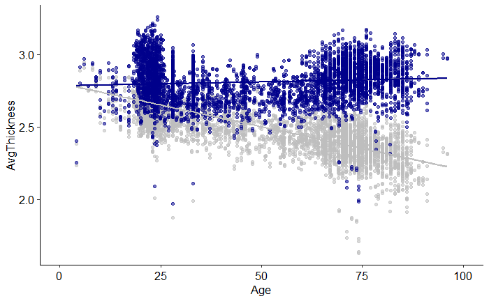

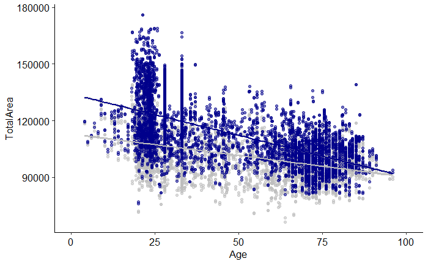

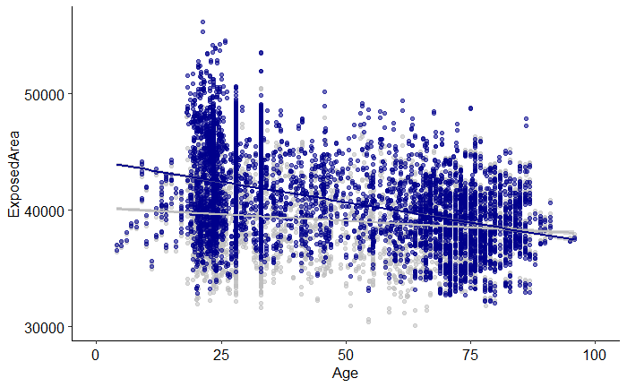

### Changing the age reference, or age target

Let’s change to 25 years old. At this age we expect the brain already finished development and did not started aging.

```r
Age.cor = 25 #

data <- data %>%
  mutate(
    AvgThickness_age_decay = AvgThickness - c_AvgThickness * (Age - Age.cor),
    TotalArea_age_decay = TotalArea - c_TotalArea * (Age - Age.cor),
    ExposedArea_age_decay = ExposedArea - c_ExposedArea * (Age - Age.cor),
    K_age_decay = log10(TotalArea_age_decay) + 1/4*log10(AvgThickness_age_decay^2) - 5/4*log10(ExposedArea_age_decay),
    I_age_decay = log10(TotalArea_age_decay) + log10(ExposedArea_age_decay) + log10(AvgThickness_age_decay^2),
    S_age_decay = 3/2*log10(TotalArea_age_decay) + 3/4*log10(ExposedArea_age_decay) - 9/4*log10(AvgThickness_age_decay^2),
    Knorm_age_decay = K_age_decay/sqrt(1 + (1/4)^2 + (-5/4)^2),
    Snorm_age_decay = S_age_decay/sqrt((3/2)^2 + (3/4)^2 + (9/4)^2),
    Inorm_age_decay = I_age_decay/sqrt(1^2+1^2+1^2))
```

How changing the correction Age affects of Cortical Thickness and K deaging:

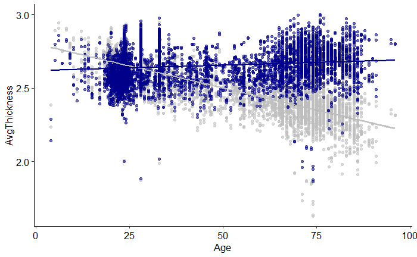

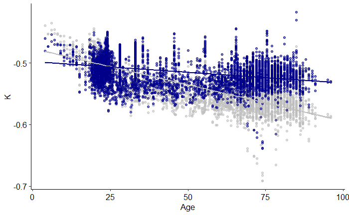

# Harmonization

The harmonization procedure is useful to combine multiple datasets to improve the statistical power, expand the findings to other Samples and studies and validating the findings of a local Sample to global results. The heterogeneous methodology limits these comparisons, so we will handle the differences to work the data.

The harmonization procedure follow the same premises as the deaging, but here we assume all samples follow the same trend. We will them remove the Type II Error by subtracting for each datapoint the residue of its sample.

## Visualization of Type II Error

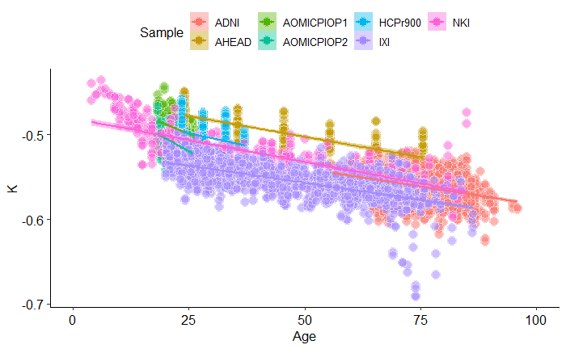

If we extrapolate the regression lines we have:

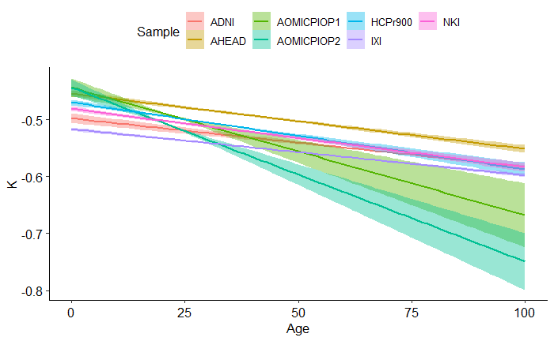

To do this we need to consider the Sample as a random effect in a Linear Mixed Model. The residue will be then the difference between each Sample intercept and a *general* intercept for all datapoints (black dashed line).

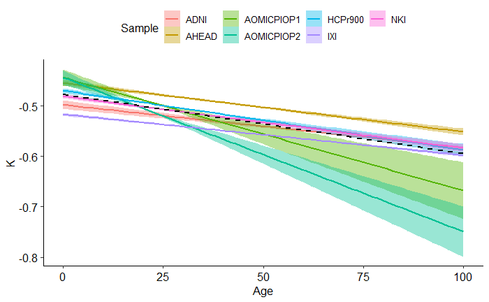

```r
data_rate <-
  filter(
    data,
    ROI == "hemisphere",
    Diagnostic == "CTL"
  )

data_rate$Sample <- as.factor(data_rate$Sample)
```

## Removing the sample effect - substracting the intercept

As in the deaging, we harmonize the raw measurements. We will use the Cortical Thickness as example again.

```r
## AvgThickness \~ Age ----

m.1 <- lme4::lmer(AvgThickness ~ Age + (1|Sample), data = data_rate) # run the linear mixed model

as_tibble(ranef(m.1)) # random effects in tibble format
```

| grpvar | term | grp | condval | condsd |
| --- | --- | --- | --- | --- |
| Sample | (Intercept) | ADNI | 0.0008162885 | 0.002406123 |
| Sample | (Intercept) | AHEAD | 0.0210192220 | 0.007000413 |
| Sample | (Intercept) | AOMICPIOP1 | -0.0149689929 | 0.004889630 |
| Sample | (Intercept) | AOMICPIOP2 | -0.0289463257 | 0.004714069 |
| Sample | (Intercept) | HCPr900 | 0.0833445832 | 0.002388363 |
| Sample | (Intercept) | IXI | -0.0295800974 | 0.002984931 |
| Sample | (Intercept) | NKI | -0.0316846778 | 0.005431841 |

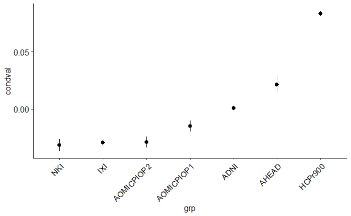

```r
ggplot(as_tibble(ranef(m.1)), aes(x = grp, y = condval)) +
  geom_pointrange(aes(ymin = condval - condsd, ymax = condval + condsd)) +
  theme_pubr() +
  theme(axis.text.x = element_text(angle = 45, hjust = 1))
```

```r
re <- as_tibble(ranef(m.1)) %>% # extract the random effects
  mutate(T_shift = condval, Sample = grp) %>% # the condval is the intercept difference for each sample. it is also a constant. here we will refer to it as shift
  dplyr::select(-c(condval, grpvar, term, condsd, grp))

data <- full_join(data, re) %>% mutate(AvgThickness_shiftc = AvgThickness - T_shift) # includign the constant in the dataset and estimanting the harmonizaed values
```

Condval equal to zero means the sample intercept is the same as the *general* regressing line.

```r
## TotalArea \~ Age ----

m.1 <- lme4::lmer(TotalArea ~ Age + (1|Sample), data = data_rate)

re <- as_tibble(ranef(m.1)) %>%
  filter(grpvar == "Sample") %>%
  mutate(AT_shift = condval, Sample = grp) %>%
  dplyr::select(-c(condval, grpvar, term, condsd, grp))

data <- full_join(data, re) %>% mutate(TotalArea_shiftc = TotalArea - AT_shift)

## ExposedArea \~ Age ----

m.1 <- lme4::lmer(ExposedArea ~ Age + (1|Sample), data = data_rate)

re <- as_tibble(ranef(m.1)) %>%
  filter(grpvar == "Sample") %>%
  mutate(AE_shift = condval, Sample = grp) %>%
  dplyr::select(-c(condval, grpvar, term, condsd, grp))

data <- full_join(data, re) %>% mutate(ExposedArea_shiftc = ExposedArea - AE_shift)
```

Re-estimating values:

```r
data <- data %>%
  mutate(
    AvgThickness_shiftc = AvgThickness - c_AvgThickness * (Age - Age.cor),
    TotalArea_shiftc = TotalArea - c_TotalArea * (Age - Age.cor),
    ExposedArea_shiftc = ExposedArea - c_ExposedArea * (Age - Age.cor),
    K_shiftc = log10(TotalArea_shiftc) + 1/4*log10(AvgThickness_shiftc^2) - 5/4*log10(ExposedArea_shiftc),
    I_shiftc = log10(TotalArea_shiftc) + log10(ExposedArea_shiftc) + log10(AvgThickness_shiftc^2),
    S_shiftc = 3/2*log10(TotalArea_shiftc) + 3/4*log10(ExposedArea_shiftc) - 9/4*log10(AvgThickness_shiftc^2),
    Knorm_shiftc = K_age_decay/sqrt(1 + (1/4)^2 + (5/4)^2),
    Snorm_shiftc = S_age_decay/sqrt((3/2)^2 + (3/4)^2 + (9/4)^2),
    Inorm_shiftc = I_age_decay/sqrt(1^2+1^2+1^2))
```

### Result (hemisphere only)

To compare the values, we will have the raw measurements in light gray, and the new values in dark blue

#### Novel measurement - K

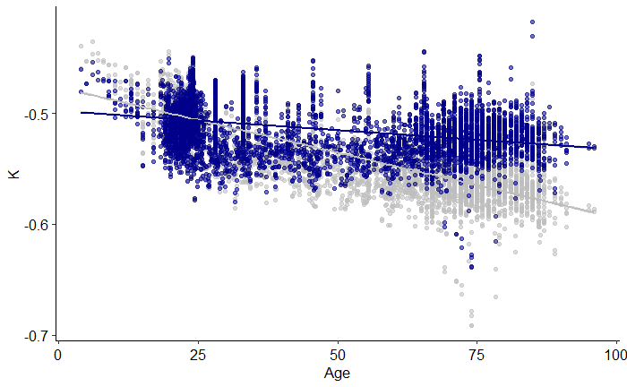

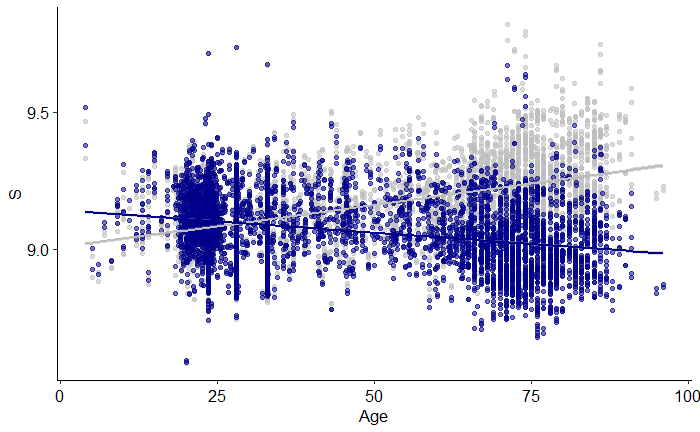

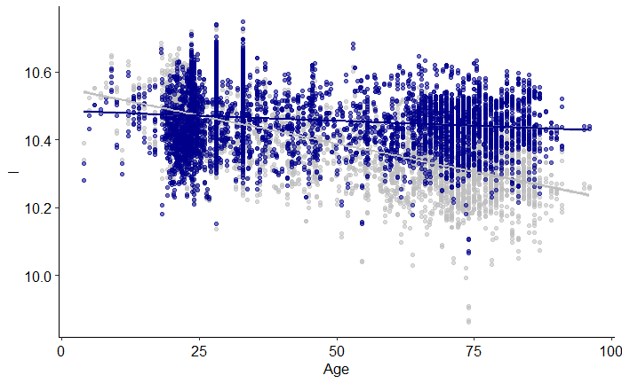

# Deaging and harmonization in one shot

Here, we used the linear version of the variables. It does not affect the final result.

## Results

# Limitations and expectations from future works

We are aware that this work is just the begging of a long trajectory in data analysis. We want to use this space to describe some concerns and already known limitations.

Both processes are still dependable on a Control subset of the data. We use the control subset as the reference since the deaging, and the harmonization can remove unwanted effects if applied directly to nontypical or pathological populations. Although, it could be helpful to measure the difference in morphological variables due to different methodologies in the same Sample (e.g., comparing acquisition protocols).

We could use higher-level functions or split the data into periods of years to avoid considering a constant rate of aging for all human lifespan. Here we are limited by the available and processed data. International consortium and open datasets should fulfill this task. We also want to keep the processes as simple as possible.

We also expect future works to provide rates from smaller brain regions, leading to studies in precise ROI.